# Análisis de sentimientos con R - Léxico Afinn

Juan Bosco Mendoza Vega

15 de abril de 2018

En este documento revisaremos cómo realizar análisis de sentimientos usando **R** y el léxico Afinn.

Nos enfocaremos en algunas de las opciones que tenemos para analizar sentimientos usando R más que en los resultados específicos de los datos que usaremos, pero en el proceso veremos maneras para contestar ciertas preguntas:

- ¿Cuáles palabras han influido para determinar los sentimientos?
- ¿Qué sentimientos han sido predominantes? ¿Positivos, negativos?
- ¿Cómo han cambiado los sentimientos a través del tiempo?

Como datos usaremos la actividad de Twitter de los candidatos a la presidencia de México durante el 2018, hasta el 11 de Abril. Pero antes, preparemos nuestro entorno de trabajo.

# Preparación

Los paquetes más importantes que usaremos son **tidyverse**, que nos permite importar multiples paquetes que nos facilitarán el análisis y manipulación de datos, y **tidytext**, que contiene las herramientas para manipular texto. Además usaremos **tm** contiene herramientas de mineria de textos, **lubridate** para fechas de manera consistente, y **zoo** y **scales** que contienen funciones para realizar tareas comunes de análisis y presentación de datos. Si no cuentas con estos paquetes, puedes obtenerlos usando la función `install.packages()`

```r
library(tidyverse)
library(tidytext)
library(tm)
library(lubridate)
library(zoo)
library(scales)
```

Definimos un tema para facilitar la visualización de nuestros resultados.

```r
tema_graf <-
  theme_minimal() +
  theme(text = element_text(family = "serif"),
        panel.grid.minor = element_blank(),
        strip.background = element_rect(fill = "#EBEBEB", colour = NA),
        legend.position = "none",
        legend.box.background = element_rect(fill = "#EBEBEB", colour = NA))
```

# Importando los datos

Descargamos los datos con los tuits de los candidatos a la presidencia desde la siguiente dirección, estos han sido obtenidos usando la API de Twitter.

- https://raw.githubusercontent.com/jboscomendoza/rpubs/master/sentimientos_afinn/tuits_candidatos.csv

```r
download.file("https://raw.githubusercontent.com/jboscomendoza/rpubs/master/sentimientos_afinn/tuits_candidatos.csv",
              "tuits_candidatos.csv")
```

Leemos los tuits usando `read.csv()`. El argumento `fileEncoding = "latin1"` es importante para mostrar correctamente las vocales con tildes, la ñ y otro caracteres especiales.

```r
tuits <- read.csv("tuits_candidatos.csv", stringsAsFactors = F, fileEncoding = "latin1") %>%
  tbl_df()
```

Nuestros datos lucen así:

```r
tuits
```

```
## # A tibble: 2,660 x 4
##    status_id created_at       screen_name   text
##        <dbl> <chr>            <chr>         <chr>
##  1   7.30e17 09/05/2016 03:03 lopezobrador_ Proceso habla de vilezas de E~
##  2   7.30e17 10/05/2016 02:06 lopezobrador_ "MORENA llegó como bendición ~
##  3   7.30e17 10/05/2016 12:00 lopezobrador_ Muchas felicidades a las madr~
##  4   7.31e17 12/05/2016 04:46 lopezobrador_ "En Chihuahua, Javier Félix M~
##  5   7.31e17 13/05/2016 02:54 lopezobrador_ Están desatados priístas, pan~
##  6   7.31e17 13/05/2016 19:13 lopezobrador_ No sé a ustedes, pero a mí lo~
##  7   7.32e17 15/05/2016 03:27 lopezobrador_ Luego de la explosión en Paja~
##  8   7.32e17 16/05/2016 02:20 lopezobrador_ Hoy 15 de mayo nuestro sincer~
##  9   7.32e17 17/05/2016 02:56 lopezobrador_ "El periódico Financial Times~
## 10   7.33e17 18/05/2016 17:57 lopezobrador_ Sandra Ávila Beltrán, conocid~
## # ... with 2,650 more rows
```

La versión que usaremos es una traducción automática, de inglés a español, de la versión del léxico presente en el conjunto de datos `sentiments` de *tidytext*, con algunas correcciones manuales. Por supuesto, esto quiere decir que este léxico tendrá algunos defectos, pero será suficiente para nuestro análisis.

Descargamos este léxico de la siguiente dirección:

- https://raw.githubusercontent.com/jboscomendoza/rpubs/master/sentimientos_afinn/lexico_afinn.en.es.csv

```r
download.file("https://raw.githubusercontent.com/jboscomendoza/rpubs/master/sentimientos_afinn/lexico_afinn.en.es.csv",
              "lexico_afinn.en.es.csv")
```

De nuevo usamos la función `read.csv()` para importar los datos.

```r
afinn <- read.csv("lexico_afinn.en.es.csv", stringsAsFactors = F, fileEncoding = "latin1") %>%
  tbl_df()
```

Este léxico luce así:

```r
afinn
```

```
## # A tibble: 2,476 x 3
##    Palabra     Puntuacion Word
##    <chr>            <int> <chr>
##  1 a bordo              1 aboard
##  2 abandona            -2 abandons
##  3 abandonado          -2 abandoned
##  4 abandonar           -2 abandon
##  5 abatido             -2 dejected
##  6 abatido             -3 despondent
##  7 aborrece            -3 abhors
##  8 aborrecer           -3 abhor
##  9 aborrecible         -3 abhorrent
## 10 aborrecido          -3 abhorred
## # ... with 2,466 more rows
```

Tenemos tres columnas. Una con palabras en español, su puntuación y una tercera columna con la misma palabra, en inglés.

Hora de preparar nuestros datos para análisis.

# Peparando los datos

## Fechas

Por último, usamos `filter()` de *dplyr* para seleccionar sólo los tuits hechos en el 2018.

```r
tuits <-
  tuits %>%
  separate(created_at, into = c("Fecha", "Hora"), sep = " ") %>%
  separate(Fecha, into = c("Dia", "Mes", "Periodo"), sep = "/",
           remove = FALSE) %>%
  mutate(Fecha = dmy(Fecha),
         Semana = week(Fecha) %>% as.factor(),
         text = tolower(text)) %>%
  filter(Periodo == 2018)
```

## Convirtiendo tuits en palabras

Además, aprovechamos para crear una columna con `mutate()` de *dplyr* a las palabras como **Positiva** o **Negativa**. Llamaremos esta columna **Tipo** y cambiamos el nombre de la columna **screen_name** a **Candidato**.

```r
tuits_afinn <-
  tuits %>%
  unnest_tokens(input = "text", output = "Palabra") %>%
  inner_join(afinn, ., by = "Palabra") %>%
  mutate(Tipo = ifelse(Puntuacion > 0, "Positiva", "Negativa")) %>%
  rename("Candidato" = screen_name)
```

Obtenemos también una puntuación por tuit, usando `group_by()` y `summarise()` de *dplyr*, y la agregamos **tuits** para usarla después. Tambien asignamos a los tuits sin puntuación positiva o negativa un valor de 0, que indica neutralidad. Por último cambiamos el nombre de la columna **screen_name** a **Candidato**

```r
tuits <-
  tuits_afinn %>%
  group_by(status_id) %>%
  summarise(Puntuacion_tuit = mean(Puntuacion)) %>%
  left_join(tuits, ., by = "status_id") %>%
  mutate(Puntuacion_tuit = ifelse(is.na(Puntuacion_tuit), 0, Puntuacion_tuit)) %>%
  rename("Candidato" = screen_name)
```

Con esto estamos listos para empezar.

# Explorando los datos, medias por día

Empecemos revisando cuántas palabras en total y cuantas palabras únicas ha usado cada candidato con `count()`, `group_by()` y `distinct()` de *dplyr*.

```r
# Total
tuits_afinn %>%
  count(Candidato)
```

```
## # A tibble: 5 x 2
##   Candidato         n
##   <chr>         <int>
## 1 JaimeRdzNL      525
## 2 JoseAMeadeK     533
## 3 lopezobrador_   183
## 4 Mzavalagc       838
## 5 RicardoAnayaC   617
```

```r
# Únicas
tuits_afinn %>%
  group_by(Candidato) %>%
  distinct(Palabra) %>%
  count()
```

```
## # A tibble: 5 x 2
## # Groups:   Candidato [5]
##   Candidato         n
##   <chr>         <int>
## 1 JaimeRdzNL      117
## 2 JoseAMeadeK     183
## 3 lopezobrador_    73
## 4 Mzavalagc       190
## 5 RicardoAnayaC   153
```

Y veamos también las palabras positivas y negativas más usadas por cada uno de ellos, usando `map()` de *purr*, `top_n()` de `dplyr()` y *ggplot*.

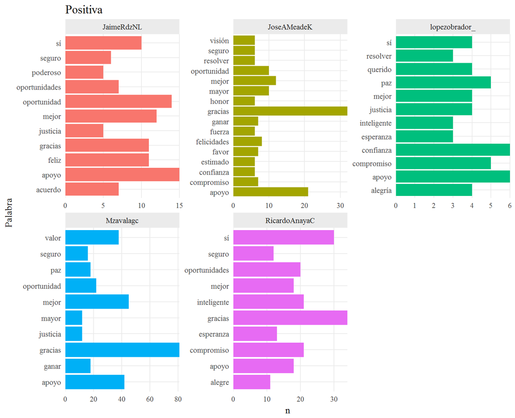

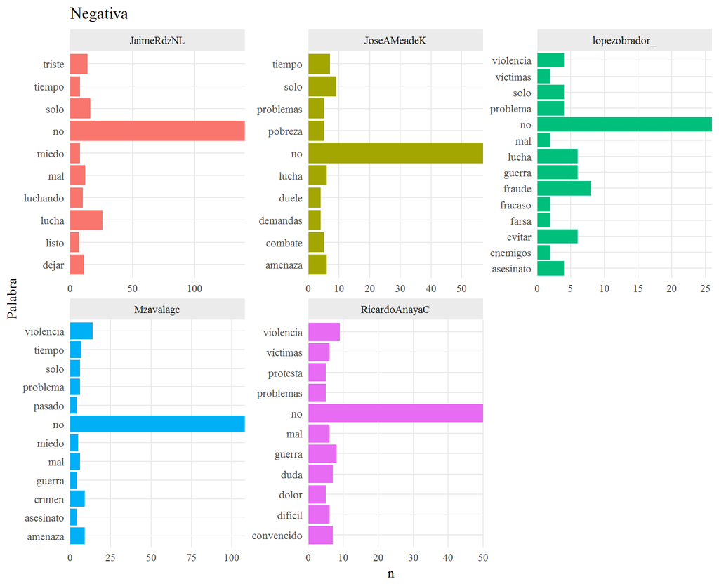

```r
map(c("Positiva", "Negativa"), function(sentimiento) {
  tuits_afinn %>%
    filter(Tipo ==  sentimiento) %>%
    group_by(Candidato) %>%
    count(Palabra, sort = T) %>%
    top_n(n = 10, wt = n) %>%
    ggplot() +
    aes(Palabra, n, fill = Candidato) +
    geom_col() +
    facet_wrap("Candidato", scales = "free") +
    scale_y_continuous(expand = c(0, 0)) +
    coord_flip() +
    labs(title = sentimiento) +
    tema_graf
})
```

Si calculamos el sentimiento de los candidatos, haciendo una suma de puntuaciones, aquellos con más palabras podrían tener puntuaciones más altas, lo cual sesgaría nuestra interpretación de la magnitud de los resultados. En un caso como este, nos conviene pensar en una medida resumen como la media para hacer una mejor interpretación de nuestros datos.

Quitamos “no” de nuestras palabras. Es una palabra muy comun en español que no necesariamente implica un sentimiento negativo. Es la palabra negativa más frecuente entre los candidatos, por lo que podría sesgar nuestros resultados.

```r
tuits_afinn <-
  tuits_afinn %>%
  filter(Palabra != "no")
```

Como deseamos observar tendencias, vamos a obtener la media de sentimientos por día, usando `group_by()` y `summarise()` y asignamos los resultados a **tuits_afinn_fecha**

```r
tuits_afinn_fecha <-
  tuits_afinn %>%
  group_by(status_id) %>%
  mutate(Suma = mean(Puntuacion)) %>%
  group_by(Candidato, Fecha) %>%
  summarise(Media = mean(Puntuacion))
```

Veamos nuestros resultados con ggplot()

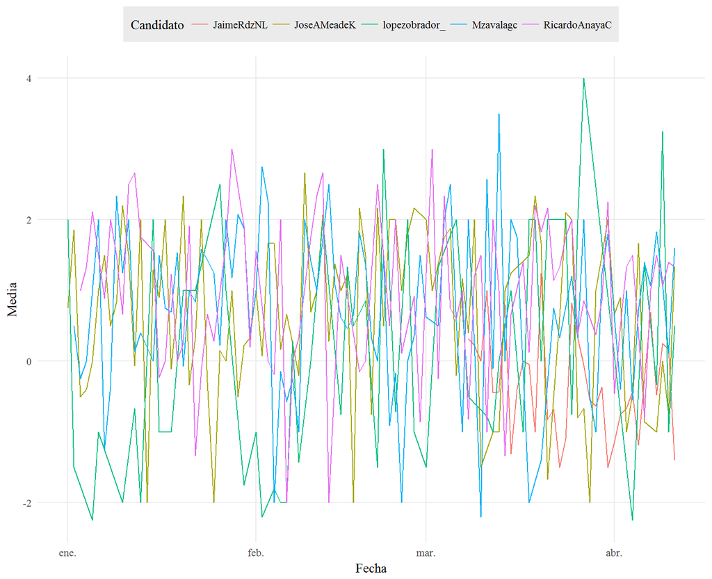

```r
tuits_afinn_fecha %>%
  ggplot() +
  aes(Fecha, Media, color = Candidato) +
  geom_line() +
  tema_graf +
  theme(legend.position = "top")
```

No nos dice mucho. Sin embargo, si separamos las líneas por candidato, usando `facet_wrap()`, será más fácil observar el las tendencias de los Candidatos.

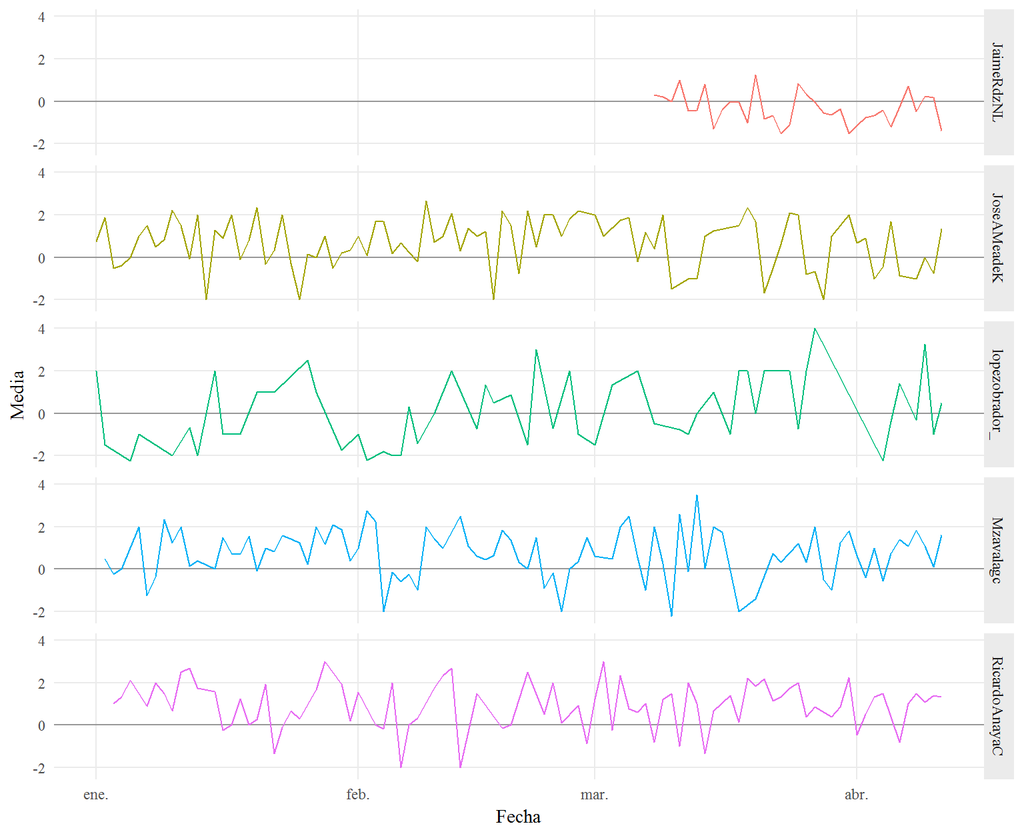

```r
tuits_afinn_fecha %>%
  ggplot() +
  aes(Fecha, Media, color = Candidato) +
  geom_hline(yintercept = 0, alpha = .35) +
  geom_line() +
  facet_grid(Candidato~.) +
  tema_graf +
  theme(legend.position = "none")
```

# Usando LOESS (regression local)

Una manera en que podemos extraer tendencias es usar el algoritmo de regresión local LOESS. Con este algoritmo trazaremos una línea que intenta ajustarse a los datos contiguos. Como sólo tenemos una observación por día, quitaremos el sombreado que indica el error estándar.

Una explicación más completa de LOESS se encuentra aquí:

- https://www.itl.nist.gov/div898/handbook/pmd/section1/pmd144.htm

Usamos la función `geom_smooth()` de *ggplot2*, con el argumento `method = "loess"` para calcular y graficar una regresión local a partir de las medias por día.

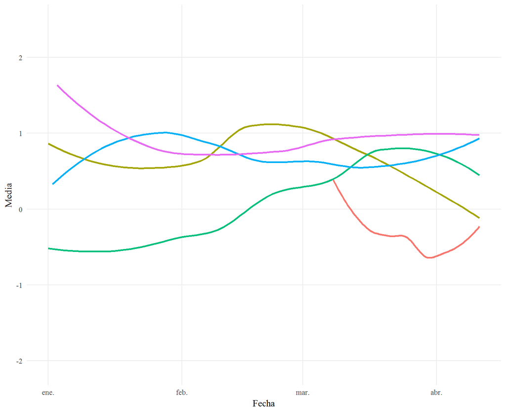

```r
tuits_afinn_fecha %>%
  ggplot() +
  aes(Fecha, Media, color = Candidato) +
  geom_smooth(method = "loess", fill = NA) +
  tema_graf
```

En realidad, podemos obtener líneas muy similares directamente de las puntuaciones.

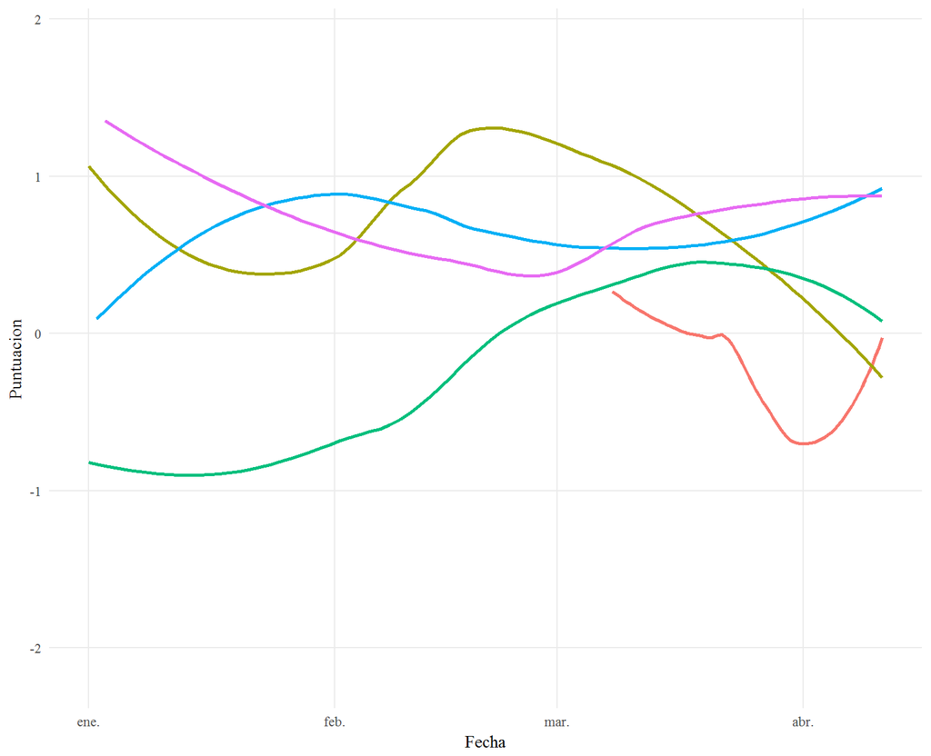

```r
tuits_afinn %>%
  ggplot() +
  aes(Fecha, Puntuacion, color = Candidato) +
  geom_smooth(method = "loess", fill = NA) +
  tema_graf
```

Si separamos las lineas por candidato y mostramos los puntos a partir de los cuales se obtienen las líneas de regresión, podemos observar con más claridad la manera en que el algoritmo LOESS llega a sus resultado. Haremos esto con `facet_wrap()` y `geom_point`.

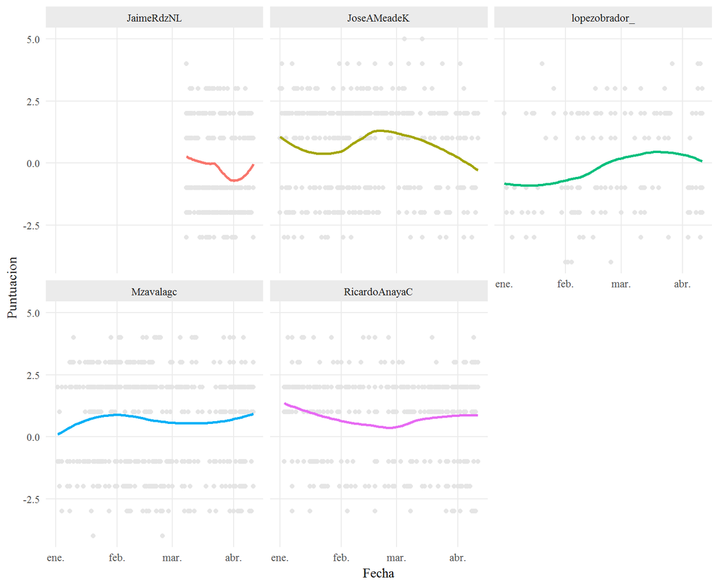

```r
tuits_afinn %>%
  ggplot() +
  aes(Fecha, Puntuacion, color = Candidato) +
  geom_point(color = "#E5E5E5") +
  geom_smooth(method = "loess", fill = NA) +
  facet_wrap(~Candidato) +
  tema_graf
```

Esto es conveniente, pues podemos identificar tendencias de datos que en apariencia no tienen ninguna. Al mismo tiempo, esto es una desventaja, pues podemos llegar a sobre ajustar la línea de regresión y, al interpretarla, llegar a conclusiones que no siempre son precisas.

Comparemos los resultados de al algoritmo LOESS con los resultados de una Regresión Lineal ordinaria, que intentará ajustar una recta.

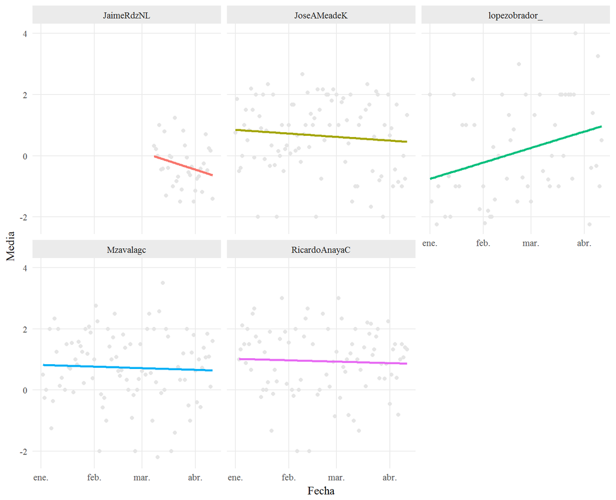

```r
tuits_afinn_fecha %>%
  ggplot() +
  aes(Fecha, Media, color = Candidato) +
  geom_point(color = "#E5E5E5") +
  geom_smooth(method = "lm", fill = NA) +
  facet_wrap(~Candidato) +
  tema_graf
```

Aun podemos observar una tendencia, pero en la mayoría de los casos no es tan “clara” como parecería usando LOESS. También podemos ver cómo es que pocos datos, es posible que valores extremos cambien notablemente la forma de una línea trazada con LOESS, de manera similar a cómo cambian la pendiente de una Regresión Lineal ordinaria. Esto es osbervable con los datos de **lopezobrador_**.

Para nuestros fines, LOESS es suficiente para darnos un panorama general en cuanto a la tendencia de sentimientos en los candidatos. No obstante, es importante ser cuidadosos con las interpretaciones que hagamos.

# Usando la media móvil

La media móvil se obtiene a partir de subconjuntos de datos que se encuentran ordenados. En nuestro ejemplo, tenemos nuestros datos ordenados por fecha, por lo que podemos crear subconjuntos de fechas consecutivas y obtener medias de ellos. En lugar de obtener una media de puntuación de todas las fechas en nuestros datos, obtenemos una media de los días 1 al 3, después de los días 2 al 4, después del 3 al 5, y así sucesivamente hasta llegar al final de nuestras fechas.

Lo que obtendríamos con esto son todos los agregados de tres días consecutivos, que en teoría debería ser menos fluctuantes que de los días individuales, es decir, más estables y probablemente más apropiados para identificar tendencias.

Crearemos medias móviles usando `rollmean()` de *zoo*. Con esta función calculamos la media de cada tres días y la graficamos con `ggplot`.

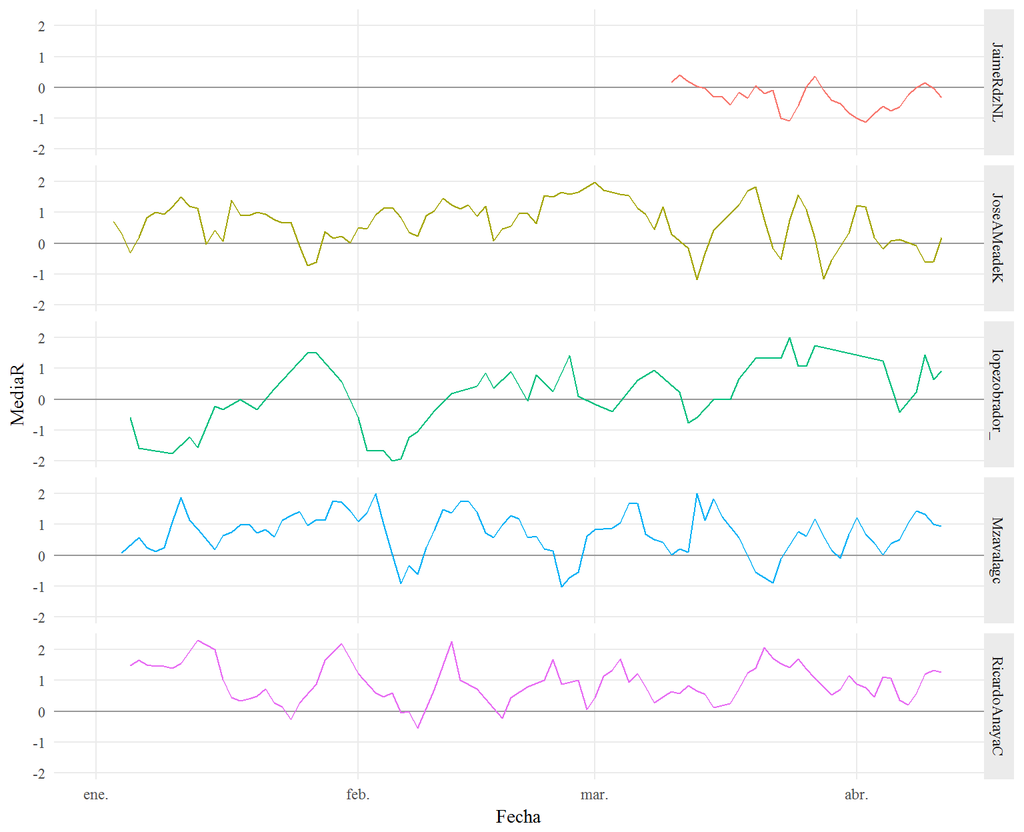

```r
tuits_afinn_fecha %>%
  group_by(Candidato) %>%
  mutate(MediaR = rollmean(Media, k = 3, align = "right", na.pad = TRUE)) %>%
  ggplot() +
  aes(Fecha, MediaR, color = Candidato) +
  geom_hline(yintercept = 0, alpha = .35) +
  geom_line() +
  facet_grid(Candidato~.) +
  tema_graf
```

Si comparamos con la gráfica que obtuvimos a partir de las medias por día, esta es menos “ruidosa” y nos permite observar más fácilmente las tendencias.

# Comparando sentimientos positivos y negativos

Es posible que no nos interen las puntuaciones de sentimiento de cada día, sólo si la tendencia ha sido positiva o negativa. Como ya etiquetamos la puntuación de nuestros tuits como “Positiva” y “Negativa”, sólo tenemos que obtener proporciones y graficar.

Primero, veamos que proporción de tuits fueron positivos y negativos, para todo el 2018 y para cada Candidato. Usamos `geom_col()` de *ggplot2* para elegir el tipo de gráfica y la función `percent_format()` de *scales* para dar formato de porcentaje al eje y.

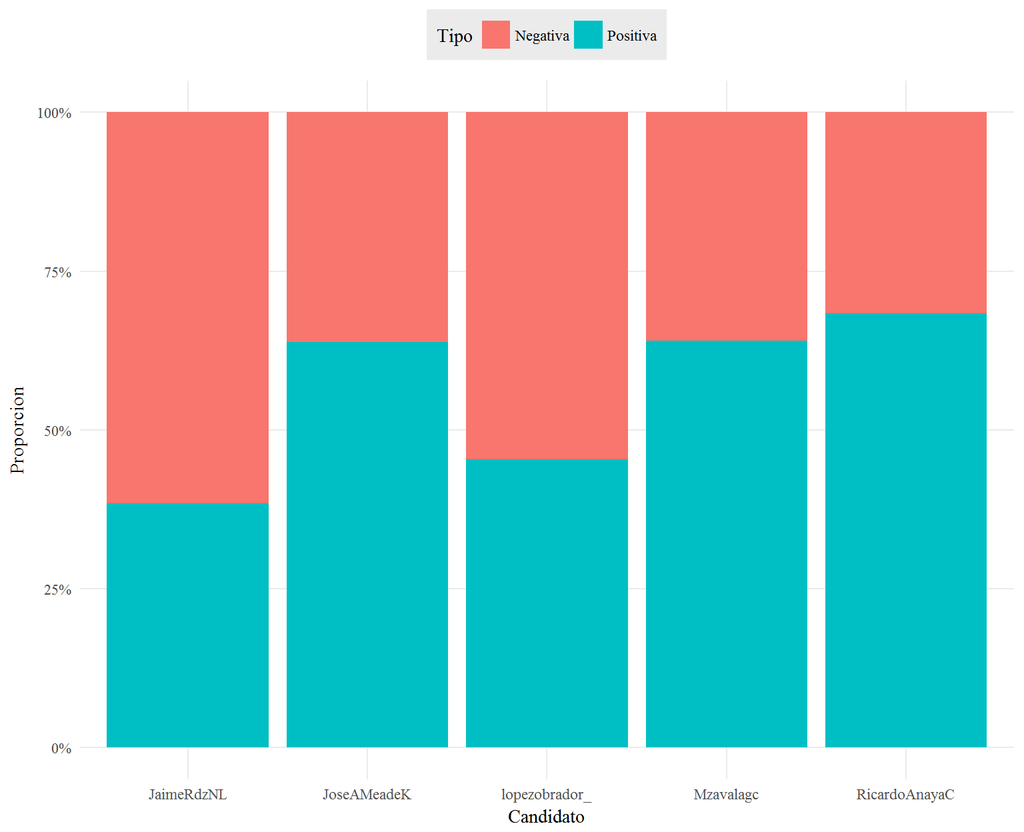

```r
tuits_afinn %>%
  count(Candidato, Tipo) %>%
  group_by(Candidato) %>%
  mutate(Proporcion = n / sum(n)) %>%
  ggplot() +
  aes(Candidato, Proporcion, fill = Tipo) +
  geom_col() +
  scale_y_continuous(labels = percent_format()) +
  tema_graf +
  theme(legend.position = "top")
```

Si obtnemos la proporción de positiva y negativa por día, podemos obsrvar cómo cambia con el paso del tiempo. Usamos el argumento `width = 1` de `geom_col()` para quitar el espacio entre barras individuales y el argumento `expand = c(0, 0)` de `scale_x_date()` para quitar el espacio en blanco en los extremos del eje x de nuestra gráfica (intenta crear esta gráfica sin este argumento para ver la diferencia).

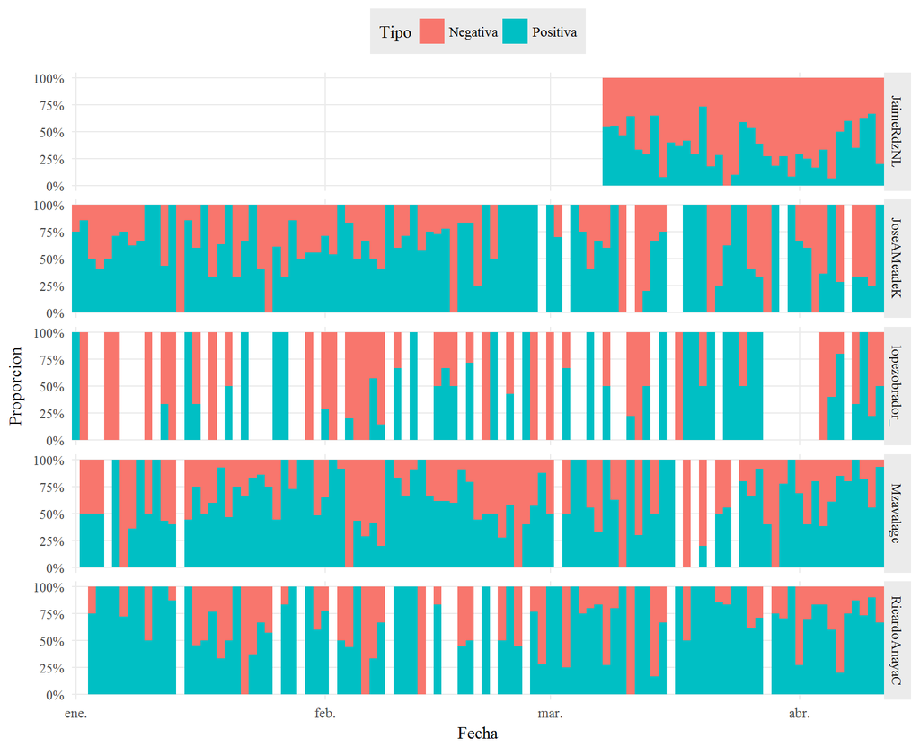

```r
tuits_afinn %>%
  group_by(Candidato, Fecha) %>%
  count(Tipo) %>%
  mutate(Proporcion = n / sum(n)) %>%
  ggplot() +
  aes(Fecha, Proporcion, fill = Tipo) +
  geom_col(width = 1) +
  facet_grid(Candidato~.) +
  scale_y_continuous(labels = percent_format()) +
  scale_x_date(expand = c(0, 0)) +
  tema_graf +
  theme(legend.position = "top")
```

En este ejemplo, como los candidatos no tuitearon todos los días, tenemos algunos huecos en nuestra gráfica. De todos modos es posible observar la tendencia general de la mayoría de ellos.

## Bloxplots (diagrama caja y bigotes)

Una manera más en la que podemos visualizar la puntuación sentimientos es usando *boxplots*. En nuestro análisis quizás no es la manera ideal de presentar los resultados dado que tenemos una cantidad relativamente baja de casos por Candidato. Sin embargo, vale la pena echar un vistazo, pues es una herramienta muy útil cuando tenemos una cantidad considerable de casos por analizar.

En este tipo de gráficos, la caja representa el 50% de los datos, su base se ubica en el primer cuartil (25% de los datos debajo) y su tope en el tercer cuartil (75% de los datos debajo). La línea dentro de la caja representa la mediana o secundo cuartil (50% de los datos debajo). Los bigotes se extienden hasta abarcar un largo de 1.5 veces el alto de la caja, o hasta abarcar todos los datos, lo que ocurra primero. Los puntos son los *outliers*, datos extremos que salen del rango de los bigotes. Por todo lo anterior, esta visualización es preferible cuando tenemos datos con distribuciones similares a una normal.

Usamos la función `geom_boxplot()` de *ggplot2* para elegir el tipo de gráfica. Creamos un boxplot por candidato.

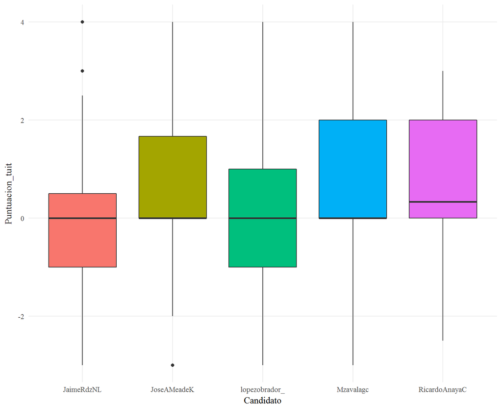

```r
tuits %>%
  ggplot() +
  aes(Candidato, Puntuacion_tuit, fill = Candidato) +
  geom_boxplot() +
  tema_graf
```

También podemos crear boxplots para ver cambios a través del tiempo, sólo tenemos que agrupar nuestros datos. Como nuestros datos ya tienen una columna para el mes del año, usaremos esa como variable de agrupación. Nota que usamos `factor()` dentro de `mutate()` para cambiar el tipo de dato de Mes, en R los boxplots necesitan una variable discreta en el eje x para mostrarse correctamente.

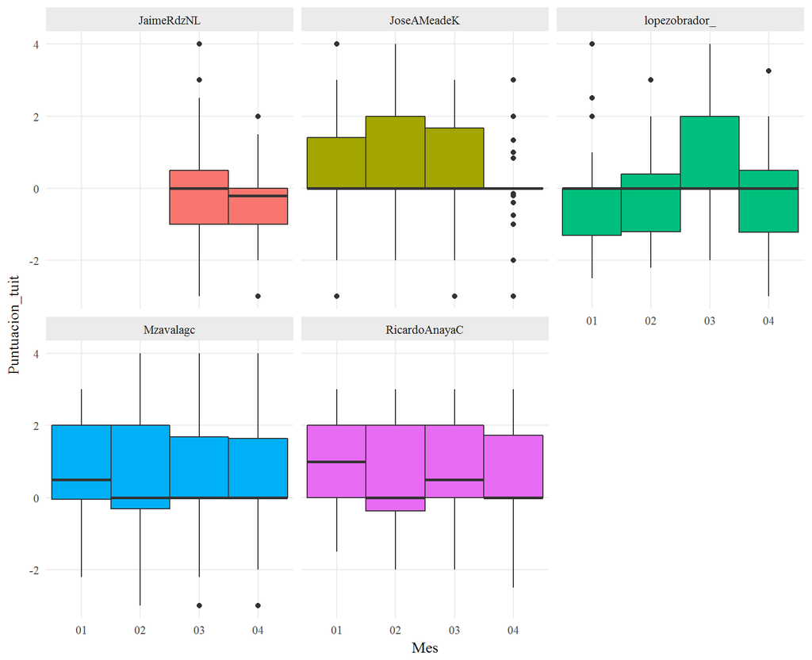

```r
tuits %>%
  mutate(Mes = factor(Mes)) %>%
  ggplot() +
  aes(Mes, Puntuacion_tuit, fill = Candidato) +
  geom_boxplot(width = 1) +
  facet_wrap(~Candidato) +
  tema_graf +
  theme(legend.position = "none")
```

# Usando densidades

Por último, podemos analizar las tendencias de sentimientos usando las funciones de densidad de las puntuaciones. *ggplot2* tiene la función `geom_density()` que hace muy fácil crear y graficar estas funciones.

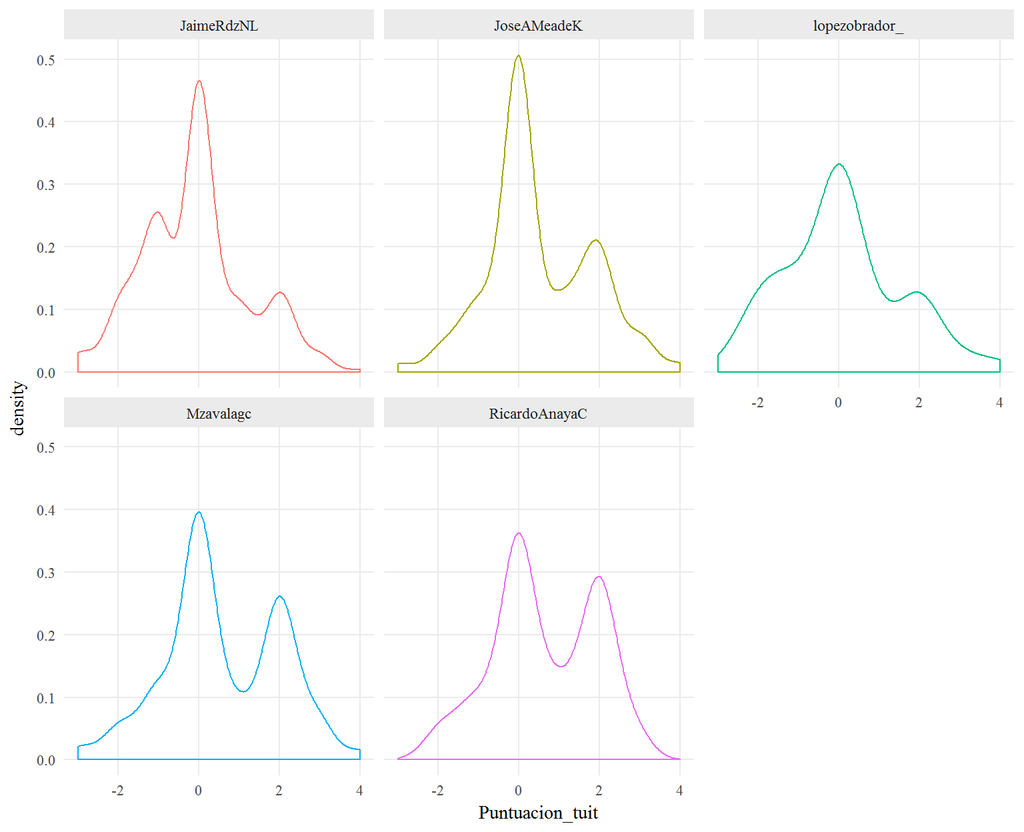

```r
tuits %>%
  ggplot() +
  aes(Puntuacion_tuit, color = Candidato) +
  geom_density() +
  facet_wrap(~Candidato) +
  tema_graf
```

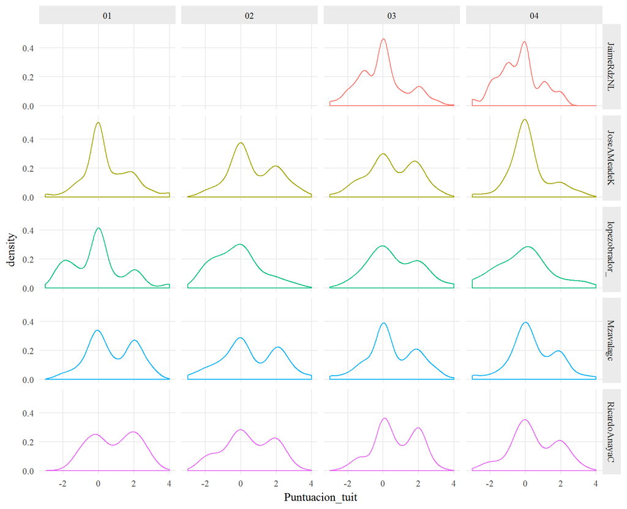

```r
tuits %>%
  ggplot() +
  aes(Puntuacion_tuit, color = Candidato) +
  geom_density() +
  facet_grid(Candidato~Mes) +
  tema_graf
```

# Para concluir

En este artículo revisamos algunas de las estrategias principales para analizar sentimientos con R, usando el léxico Afinn. Este léxico le asigna una puntuación a las palabras, de acuerdo a su contenido, que puede ser positivo o negativo.

En realidad, que la puntuación sea de tipo numérico es lo nos abre una amplia gama de posibilidades para analizar sentimientos usando el léxico Afinn. Con conjuntos de datos más grandes que el que usamos en este ejemplo, es incluso plausible pensar en análisis más complejos, por ejemplo, establer correlaciones y crear conglomerados.

Aunque no nos adentramos al análisis de los resultados que obtuvimos con nuestros datos, algunas tendencias se hicieron evidentes rápidamente. Por ejemplo, la mayoría de los candidatos ha tendido a tuitear de manera positiva. Con un poco de conocimiento del tema, sin duda podríamos encontrar información útil e interesante.

Dudas, comentarios y correcciones son bienvenidas:

- jboscomendoza@gmail.com

El código y los datos usados en este documento se encuentran en Github:

- https://github.com/jboscomendoza/rpubs/tree/master/sentimientos_afinn